# lab4

```
            МІНІСТЕРСТВО ОСВІТИ І НАУКИ УКРАЇНИ
        НАЦІОНАЛЬНИЙ УНІВЕРСИТЕТ "ЛЬВІВСЬКА ПОЛІТЕХНІКА"
                        Інститут ІКНІ
                        Кафедра СШІ


                    Лабораторна робота № 4
        з дисципліни: “Глибинне навчання та нейронні мережі”

Тема : Автоенкодери та їх типи. Імплементація за допомогою Keras.
Мета роботи : Імплементувати автоенкодер за допомогою Keras та осягнути їх суть.


                        Виконала:
                        ст. гр. ШІ-32
                        Труш Соломія
```

### ЗАВДАННЯ

- Провести дослідження двох автоенкодерів, що описані вище (глибокий автоенкодер та конволюційний автоенкодер).
- Поміняти параметри моделі глибокого автоекодера для досягнення більшої точності і провести декілька експериментів.
- Поміняти параметри моделі конволюційного автоенкодера, можливо додати ще шари конволюції та пулінга (upsampling) і перебудувати архітектуру моделі.
- Дослідити який з автоекодерів виділяє локальні особливості краще і на яких даних.
- Спробувати по різному нанести шум на зображення і за допомогою автоенкодера відновити дані.

## 1. Завантаження бібліотек

```python
import numpy as np
import matplotlib.pyplot as plt
import matplotlib.gridspec as gridspec

import tensorflow as tf
from tensorflow import keras
from tensorflow.keras.layers import Dense, Input, Conv2D, MaxPool2D, UpSampling2D, BatchNormalization, Dropout, Flatten, Reshape
from tensorflow.keras.models import Model
from tensorflow.keras.callbacks import EarlyStopping
from sklearn.model_selection import train_test_split

print(f'TensorFlow version: {tf.__version__}')
print(f'Keras version: {keras.__version__}')
```

```
TensorFlow version: 2.19.0
Keras version: 3.13.2
```

## 2. Підготовка даних (Fashion-MNIST)

```
Train: (48000, 28, 28), Val: (12000, 28, 28), Test: (10000, 28, 28)
```

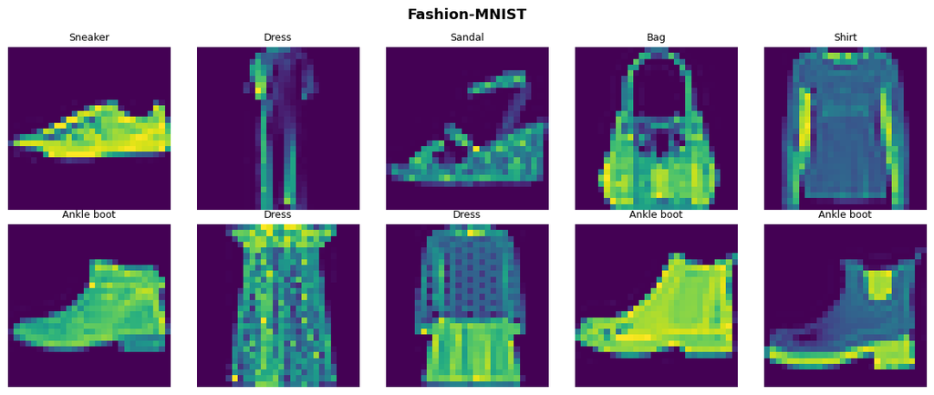

```python
(x_train_full, y_train_full), (x_test, y_test) = keras.datasets.fashion_mnist.load_data()

class_names = ['T-shirt/top','Trouser','Pullover','Dress','Coat',
               'Sandal','Shirt','Sneaker','Bag','Ankle boot']

x_train_full = x_train_full.astype('float32') / 255.0
x_test = x_test.astype('float32') / 255.0

x_train, x_val, y_train, y_val = train_test_split(
    x_train_full, y_train_full, test_size=0.2, random_state=42
)

print(f'Train: {x_train.shape}, Val: {x_val.shape}, Test: {x_test.shape}')

fig, axes = plt.subplots(2, 5, figsize=(12, 5))
for i, ax in enumerate(axes.flat):
    ax.imshow(x_train[i])
    ax.set_title(class_names[y_train[i]], fontsize=9)
    ax.axis('off')
plt.suptitle('Fashion-MNIST', fontsize=13, fontweight='bold')
plt.tight_layout()
plt.show()
```

## 3. UseCase 1: Глибокий (Dense) Автоенкодер — Реконструкція зображень

### 3.1 Базова модель (Baseline)

```python
# Reshape (N, 28, 28) -> (N, 784)
x_train_flat = x_train.reshape(-1, 784)
x_val_flat   = x_val.reshape(-1, 784)
x_test_flat  = x_test.reshape(-1, 784)

# Basic architecture
def build_dense_autoencoder_baseline():

    # input layer
    input_layer = Input(shape=(784,))

    # encoding architecture
    encode_layer1 = Dense(1500, activation='relu')(input_layer)
    encode_layer2 = Dense(1000, activation='relu')(encode_layer1)
    encode_layer3 = Dense(500, activation='relu')(encode_layer2)

    # latent view
    latent_view = Dense(10, activation='sigmoid')(encode_layer3)

    # decoding architecture
    decode_layer1 = Dense(500, activation='relu')(latent_view)
    decode_layer2 = Dense(1000, activation='relu')(decode_layer1)
    decode_layer3 = Dense(1500, activation='relu')(decode_layer2)

    # output layer
    output_layer = Dense(784)(decode_layer3)
    model = Model(input_layer, output_layer, name='Dense_AE_Baseline')
    return model

dense_ae_base = build_dense_autoencoder_baseline()
dense_ae_base.summary()
```

```
Model: "Dense_AE_Baseline"
```

```
┏━━━━━━━━━━━━━━━━━━━━━━━━━━━━━━━━━┳━━━━━━━━━━━━━━━━━━━━━━━━┳━━━━━━━━━━━━━━━┓
┃ Layer (type)                    ┃ Output Shape           ┃       Param # ┃
┡━━━━━━━━━━━━━━━━━━━━━━━━━━━━━━━━━╇━━━━━━━━━━━━━━━━━━━━━━━━╇━━━━━━━━━━━━━━━┩
│ input_layer_2 (InputLayer)      │ (None, 784)            │             0 │
├─────────────────────────────────┼────────────────────────┼───────────────┤
│ dense (Dense)                   │ (None, 1500)           │     1,177,500 │
├─────────────────────────────────┼────────────────────────┼───────────────┤
│ dense_1 (Dense)                 │ (None, 1000)           │     1,501,000 │
├─────────────────────────────────┼────────────────────────┼───────────────┤
│ dense_2 (Dense)                 │ (None, 500)            │       500,500 │
├─────────────────────────────────┼────────────────────────┼───────────────┤
│ dense_3 (Dense)                 │ (None, 10)             │         5,010 │
├─────────────────────────────────┼────────────────────────┼───────────────┤
│ dense_4 (Dense)                 │ (None, 500)            │         5,500 │
├─────────────────────────────────┼────────────────────────┼───────────────┤
│ dense_5 (Dense)                 │ (None, 1000)           │       501,000 │
├─────────────────────────────────┼────────────────────────┼───────────────┤
│ dense_6 (Dense)                 │ (None, 1500)           │     1,501,500 │
├─────────────────────────────────┼────────────────────────┼───────────────┤
│ dense_7 (Dense)                 │ (None, 784)            │     1,176,784 │
└─────────────────────────────────┴────────────────────────┴───────────────┘
```

```
 Total params: 6,368,794 (24.30 MB)
```

```
 Trainable params: 6,368,794 (24.30 MB)
```

```
 Non-trainable params: 0 (0.00 B)
```

```python
dense_ae_base.compile(optimizer='adam', loss='mse')

early_stop = EarlyStopping(monitor='val_loss', patience=5, restore_best_weights=True, verbose=1)

history_base = dense_ae_base.fit(
    x_train_flat, x_train_flat,
    epochs=30,
    batch_size=256,
    validation_data=(x_val_flat, x_val_flat),
    callbacks=[early_stop],
    verbose=1
)
```

```
188/188 ━━━━━━━━━━━━━━━━━━━━ 8s 20ms/step - loss: 0.0502 - val_loss: 0.0306
188/188 ━━━━━━━━━━━━━━━━━━━━ 1s 6ms/step - loss: 0.0253 - val_loss: 0.0226
188/188 ━━━━━━━━━━━━━━━━━━━━ 1s 6ms/step - loss: 0.0213 - val_loss: 0.0199
188/188 ━━━━━━━━━━━━━━━━━━━━ 3s 13ms/step - loss: 0.0191 - val_loss: 0.0183
188/188 ━━━━━━━━━━━━━━━━━━━━ 4s 9ms/step - loss: 0.0177 - val_loss: 0.0172
188/188 ━━━━━━━━━━━━━━━━━━━━ 1s 6ms/step - loss: 0.0167 - val_loss: 0.0165
188/188 ━━━━━━━━━━━━━━━━━━━━ 1s 6ms/step - loss: 0.0161 - val_loss: 0.0159
188/188 ━━━━━━━━━━━━━━━━━━━━ 1s 6ms/step - loss: 0.0155 - val_loss: 0.0157
188/188 ━━━━━━━━━━━━━━━━━━━━ 1s 6ms/step - loss: 0.0150 - val_loss: 0.0150
188/188 ━━━━━━━━━━━━━━━━━━━━ 1s 6ms/step - loss: 0.0147 - val_loss: 0.0147
188/188 ━━━━━━━━━━━━━━━━━━━━ 1s 7ms/step - loss: 0.0145 - val_loss: 0.0145
188/188 ━━━━━━━━━━━━━━━━━━━━ 1s 7ms/step - loss: 0.0141 - val_loss: 0.0143
188/188 ━━━━━━━━━━━━━━━━━━━━ 2s 8ms/step - loss: 0.0139 - val_loss: 0.0140
188/188 ━━━━━━━━━━━━━━━━━━━━ 2s 7ms/step - loss: 0.0136 - val_loss: 0.0140
188/188 ━━━━━━━━━━━━━━━━━━━━ 2s 9ms/step - loss: 0.0134 - val_loss: 0.0135
188/188 ━━━━━━━━━━━━━━━━━━━━ 1s 7ms/step - loss: 0.0132 - val_loss: 0.0134
188/188 ━━━━━━━━━━━━━━━━━━━━ 1s 6ms/step - loss: 0.0130 - val_loss: 0.0131
188/188 ━━━━━━━━━━━━━━━━━━━━ 1s 6ms/step - loss: 0.0129 - val_loss: 0.0132
188/188 ━━━━━━━━━━━━━━━━━━━━ 1s 7ms/step - loss: 0.0126 - val_loss: 0.0130
188/188 ━━━━━━━━━━━━━━━━━━━━ 1s 7ms/step - loss: 0.0125 - val_loss: 0.0129
188/188 ━━━━━━━━━━━━━━━━━━━━ 2s 6ms/step - loss: 0.0125 - val_loss: 0.0127
188/188 ━━━━━━━━━━━━━━━━━━━━ 1s 6ms/step - loss: 0.0122 - val_loss: 0.0126
188/188 ━━━━━━━━━━━━━━━━━━━━ 1s 6ms/step - loss: 0.0121 - val_loss: 0.0126
188/188 ━━━━━━━━━━━━━━━━━━━━ 1s 6ms/step - loss: 0.0121 - val_loss: 0.0124
188/188 ━━━━━━━━━━━━━━━━━━━━ 1s 6ms/step - loss: 0.0120 - val_loss: 0.0123
188/188 ━━━━━━━━━━━━━━━━━━━━ 1s 6ms/step - loss: 0.0119 - val_loss: 0.0123
188/188 ━━━━━━━━━━━━━━━━━━━━ 1s 6ms/step - loss: 0.0118 - val_loss: 0.0125
188/188 ━━━━━━━━━━━━━━━━━━━━ 1s 7ms/step - loss: 0.0118 - val_loss: 0.0122
188/188 ━━━━━━━━━━━━━━━━━━━━ 2s 6ms/step - loss: 0.0117 - val_loss: 0.0123
188/188 ━━━━━━━━━━━━━━━━━━━━ 1s 6ms/step - loss: 0.0116 - val_loss: 0.0121
Restoring model weights from the end of the best epoch: 30.
```

```python
def plot_loss(history, title='Loss'):
    plt.figure(figsize=(8, 4))
    plt.plot(history.history['loss'],     label='Train Loss', linewidth=2)
    plt.plot(history.history['val_loss'], label='Val Loss',   linewidth=2)
    plt.title(title, fontsize=13, fontweight='bold')
    plt.xlabel('Epoch')
    plt.ylabel('MSE Loss')
    plt.legend()
    plt.grid(True, alpha=0.3)
    plt.tight_layout()
    plt.show()
```

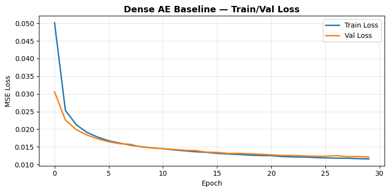

```python
plot_loss(history_base, 'Dense AE Baseline — Train/Val Loss')
```

```python
def show_reconstructions(model, x_flat, n=8, title='Реконструкція'):
    preds = model.predict(x_flat[:n], verbose=0)
    fig, axes = plt.subplots(2, n, figsize=(2*n, 5))
    for i in range(n):
        axes[0, i].imshow(x_flat[i].reshape(28, 28))
        axes[0, i].axis('off')
        axes[1, i].imshow(preds[i].reshape(28, 28))
        axes[1, i].axis('off')
    axes[0, 0].set_ylabel('Оригінал', fontsize=11)
    axes[1, 0].set_ylabel('Відновлено', fontsize=11)
    plt.suptitle(title, fontsize=13, fontweight='bold')
    plt.tight_layout()
    plt.show()
```

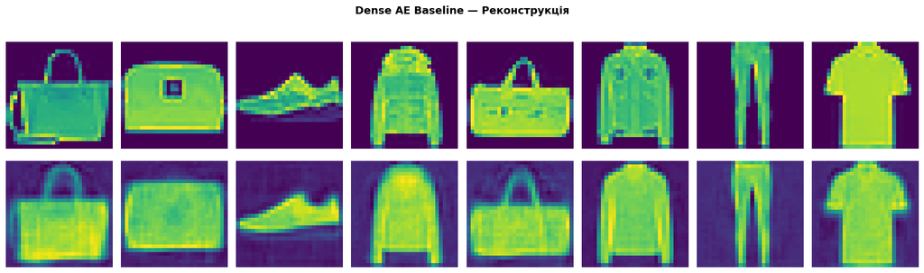

```python
show_reconstructions(dense_ae_base, x_val_flat, title='Dense AE Baseline — Реконструкція')
```

### 3.2 Експеримент 1: Покращена модель (з BatchNormalization та Dropout)

```python
def build_dense_autoencoder_improved():
    input_layer = Input(shape=(784,), name='input')

    # Encoder з BatchNorm
    e1 = Dense(1024, activation='relu', name='enc_1')(input_layer)
    e1 = BatchNormalization()(e1)
    e1 = Dropout(0.2)(e1)

    e2 = Dense(512, activation='relu', name='enc_2')(e1)
    e2 = BatchNormalization()(e2)
    e2 = Dropout(0.2)(e2)

    e3 = Dense(256, activation='relu', name='enc_3')(e2)
    e3 = BatchNormalization()(e3)

    # Latent space (більший розмір = краща якість)
    latent = Dense(32, activation='relu', name='latent')(e3)

    # Decoder
    d1 = Dense(256, activation='relu', name='dec_1')(latent)
    d1 = BatchNormalization()(d1)

    d2 = Dense(512, activation='relu', name='dec_2')(d1)
    d2 = BatchNormalization()(d2)
    d2 = Dropout(0.2)(d2)

    d3 = Dense(1024, activation='relu', name='dec_3')(d2)
    d3 = BatchNormalization()(d3)
    d3 = Dropout(0.2)(d3)

    output_layer = Dense(784, activation='sigmoid', name='output')(d3)

    model = Model(input_layer, output_layer, name='Dense_AE_Improved')
    return model
```

```python
dense_ae_imp = build_dense_autoencoder_improved()
dense_ae_imp.summary()
```

```
Model: "Dense_AE_Improved"
```

```
┏━━━━━━━━━━━━━━━━━━━━━━━━━━━━━━━━━┳━━━━━━━━━━━━━━━━━━━━━━━━┳━━━━━━━━━━━━━━━┓
┃ Layer (type)                    ┃ Output Shape           ┃       Param # ┃
┡━━━━━━━━━━━━━━━━━━━━━━━━━━━━━━━━━╇━━━━━━━━━━━━━━━━━━━━━━━━╇━━━━━━━━━━━━━━━┩
│ input (InputLayer)              │ (None, 784)            │             0 │
├─────────────────────────────────┼────────────────────────┼───────────────┤
│ enc_1 (Dense)                   │ (None, 1024)           │       803,840 │
├─────────────────────────────────┼────────────────────────┼───────────────┤
│ batch_normalization_6           │ (None, 1024)           │         4,096 │
│ (BatchNormalization)            │                        │               │
├─────────────────────────────────┼────────────────────────┼───────────────┤
│ dropout (Dropout)               │ (None, 1024)           │             0 │
├─────────────────────────────────┼────────────────────────┼───────────────┤
│ enc_2 (Dense)                   │ (None, 512)            │       524,800 │
├─────────────────────────────────┼────────────────────────┼───────────────┤
│ batch_normalization_7           │ (None, 512)            │         2,048 │
│ (BatchNormalization)            │                        │               │
├─────────────────────────────────┼────────────────────────┼───────────────┤
│ dropout_1 (Dropout)             │ (None, 512)            │             0 │
├─────────────────────────────────┼────────────────────────┼───────────────┤
│ enc_3 (Dense)                   │ (None, 256)            │       131,328 │
├─────────────────────────────────┼────────────────────────┼───────────────┤
│ batch_normalization_8           │ (None, 256)            │         1,024 │
│ (BatchNormalization)            │                        │               │
├─────────────────────────────────┼────────────────────────┼───────────────┤
│ latent (Dense)                  │ (None, 32)             │         8,224 │
├─────────────────────────────────┼────────────────────────┼───────────────┤
│ dec_1 (Dense)                   │ (None, 256)            │         8,448 │
├─────────────────────────────────┼────────────────────────┼───────────────┤
│ batch_normalization_9           │ (None, 256)            │         1,024 │
│ (BatchNormalization)            │                        │               │
├─────────────────────────────────┼────────────────────────┼───────────────┤
│ dec_2 (Dense)                   │ (None, 512)            │       131,584 │
├─────────────────────────────────┼────────────────────────┼───────────────┤
│ batch_normalization_10          │ (None, 512)            │         2,048 │
│ (BatchNormalization)            │                        │               │
├─────────────────────────────────┼────────────────────────┼───────────────┤
│ dropout_2 (Dropout)             │ (None, 512)            │             0 │
├─────────────────────────────────┼────────────────────────┼───────────────┤
│ dec_3 (Dense)                   │ (None, 1024)           │       525,312 │
├─────────────────────────────────┼────────────────────────┼───────────────┤
│ batch_normalization_11          │ (None, 1024)           │         4,096 │
│ (BatchNormalization)            │                        │               │
├─────────────────────────────────┼────────────────────────┼───────────────┤
│ dropout_3 (Dropout)             │ (None, 1024)           │             0 │
├─────────────────────────────────┼────────────────────────┼───────────────┤
│ output (Dense)                  │ (None, 784)            │       803,600 │
└─────────────────────────────────┴────────────────────────┴───────────────┘
```

```
 Total params: 2,951,472 (11.26 MB)
```

```
 Trainable params: 2,944,304 (11.23 MB)
```

```
 Non-trainable params: 7,168 (28.00 KB)
```

```python
dense_ae_imp.compile(optimizer=keras.optimizers.Adam(learning_rate=1e-3), loss='mse')

early_stop2 = EarlyStopping(monitor='val_loss', patience=5, restore_best_weights=True, verbose=1)

history_imp = dense_ae_imp.fit(
    x_train_flat, x_train_flat,
    epochs=30,
    batch_size=256,
    validation_data=(x_val_flat, x_val_flat),
    callbacks=[early_stop2],
    verbose=1
)
```

```
188/188 ━━━━━━━━━━━━━━━━━━━━ 16s 37ms/step - loss: 0.0518 - val_loss: 0.0521
188/188 ━━━━━━━━━━━━━━━━━━━━ 1s 6ms/step - loss: 0.0304 - val_loss: 0.0506
188/188 ━━━━━━━━━━━━━━━━━━━━ 2s 12ms/step - loss: 0.0265 - val_loss: 0.0237
188/188 ━━━━━━━━━━━━━━━━━━━━ 1s 6ms/step - loss: 0.0231 - val_loss: 0.0196
188/188 ━━━━━━━━━━━━━━━━━━━━ 2s 9ms/step - loss: 0.0215 - val_loss: 0.0184
188/188 ━━━━━━━━━━━━━━━━━━━━ 2s 8ms/step - loss: 0.0204 - val_loss: 0.0181
188/188 ━━━━━━━━━━━━━━━━━━━━ 3s 9ms/step - loss: 0.0200 - val_loss: 0.0167
188/188 ━━━━━━━━━━━━━━━━━━━━ 1s 7ms/step - loss: 0.0194 - val_loss: 0.0166
188/188 ━━━━━━━━━━━━━━━━━━━━ 1s 6ms/step - loss: 0.0189 - val_loss: 0.0212
188/188 ━━━━━━━━━━━━━━━━━━━━ 2s 7ms/step - loss: 0.0186 - val_loss: 0.0159
188/188 ━━━━━━━━━━━━━━━━━━━━ 1s 7ms/step - loss: 0.0182 - val_loss: 0.0239
188/188 ━━━━━━━━━━━━━━━━━━━━ 3s 7ms/step - loss: 0.0181 - val_loss: 0.0173
188/188 ━━━━━━━━━━━━━━━━━━━━ 1s 6ms/step - loss: 0.0176 - val_loss: 0.0153
188/188 ━━━━━━━━━━━━━━━━━━━━ 1s 6ms/step - loss: 0.0170 - val_loss: 0.0143
188/188 ━━━━━━━━━━━━━━━━━━━━ 1s 6ms/step - loss: 0.0169 - val_loss: 0.0141
188/188 ━━━━━━━━━━━━━━━━━━━━ 1s 6ms/step - loss: 0.0174 - val_loss: 0.0180
188/188 ━━━━━━━━━━━━━━━━━━━━ 1s 6ms/step - loss: 0.0170 - val_loss: 0.0167
188/188 ━━━━━━━━━━━━━━━━━━━━ 1s 6ms/step - loss: 0.0166 - val_loss: 0.0186
188/188 ━━━━━━━━━━━━━━━━━━━━ 1s 7ms/step - loss: 0.0167 - val_loss: 0.0142
188/188 ━━━━━━━━━━━━━━━━━━━━ 1s 8ms/step - loss: 0.0159 - val_loss: 0.0139
188/188 ━━━━━━━━━━━━━━━━━━━━ 1s 6ms/step - loss: 0.0157 - val_loss: 0.0132
188/188 ━━━━━━━━━━━━━━━━━━━━ 1s 6ms/step - loss: 0.0156 - val_loss: 0.0132
188/188 ━━━━━━━━━━━━━━━━━━━━ 1s 6ms/step - loss: 0.0155 - val_loss: 0.0155
188/188 ━━━━━━━━━━━━━━━━━━━━ 1s 6ms/step - loss: 0.0154 - val_loss: 0.0133
188/188 ━━━━━━━━━━━━━━━━━━━━ 1s 6ms/step - loss: 0.0150 - val_loss: 0.0126
188/188 ━━━━━━━━━━━━━━━━━━━━ 1s 6ms/step - loss: 0.0149 - val_loss: 0.0137
188/188 ━━━━━━━━━━━━━━━━━━━━ 1s 6ms/step - loss: 0.0148 - val_loss: 0.0131
188/188 ━━━━━━━━━━━━━━━━━━━━ 1s 6ms/step - loss: 0.0148 - val_loss: 0.0132
188/188 ━━━━━━━━━━━━━━━━━━━━ 1s 6ms/step - loss: 0.0149 - val_loss: 0.0124
188/188 ━━━━━━━━━━━━━━━━━━━━ 1s 7ms/step - loss: 0.0146 - val_loss: 0.0124
Restoring model weights from the end of the best epoch: 29.
```

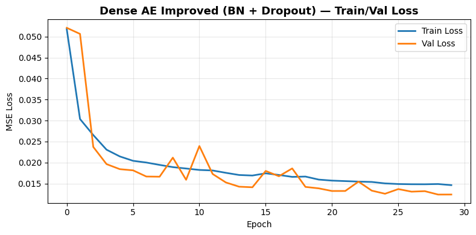

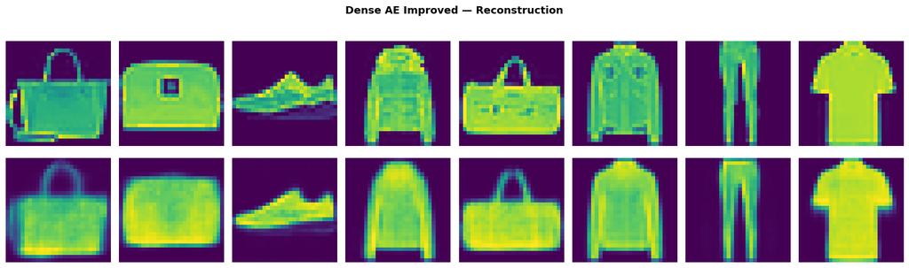

```python
plot_loss(history_imp, 'Dense AE Improved (BN + Dropout) — Train/Val Loss')
show_reconstructions(dense_ae_imp, x_val_flat, title='Dense AE Improved — Reconstruction')
```

### 3.3 Експеримент 2: Більший латентний простір vs менший

```python
def build_dense_ae_latent(latent_dim=64):
    input_layer = Input(shape=(784,))
    e = Dense(512, activation='relu')(input_layer)
    e = Dense(256, activation='relu')(e)
    latent = Dense(latent_dim, activation='relu', name='latent')(e)
    d = Dense(256, activation='relu')(latent)
    d = Dense(512, activation='relu')(d)
    output = Dense(784, activation='sigmoid')(d)
    return Model(input_layer, output, name=f'Dense_AE_latent{latent_dim}')
```

```python
results_latent = {}
for ld in [4, 16, 64]:
    print(f'\n--- Latent dim = {ld} ---')
    m = build_dense_ae_latent(ld)
    m.compile(optimizer='adam', loss='mse')
    es = EarlyStopping(monitor='val_loss', patience=5, restore_best_weights=True, verbose=0)
    h = m.fit(x_train_flat, x_train_flat,
              epochs=30, batch_size=256,
              validation_data=(x_val_flat, x_val_flat),
              callbacks=[es], verbose=0)
    val_loss = min(h.history['val_loss'])
    results_latent[ld] = (m, h, val_loss)
    print(f'Best val_loss: {val_loss:.6f}')
```

```
--- Latent dim = 4 ---
Best val_loss: 0.018301

--- Latent dim = 16 ---
Best val_loss: 0.011179

--- Latent dim = 64 ---
Best val_loss: 0.007868
```

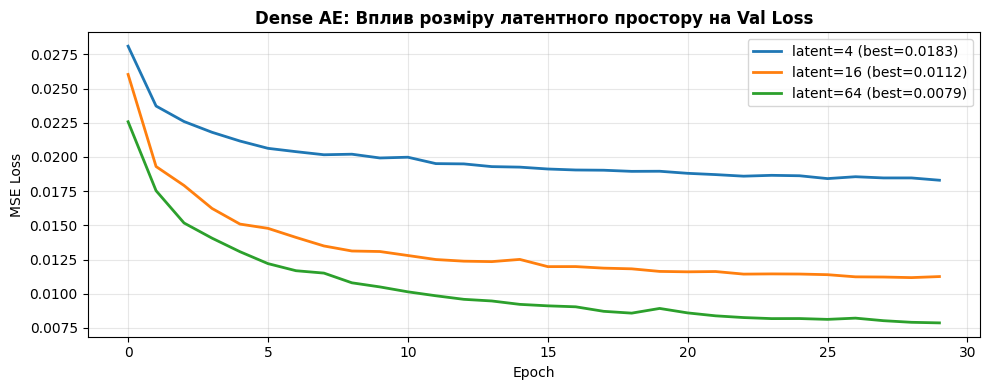

[output not shown]

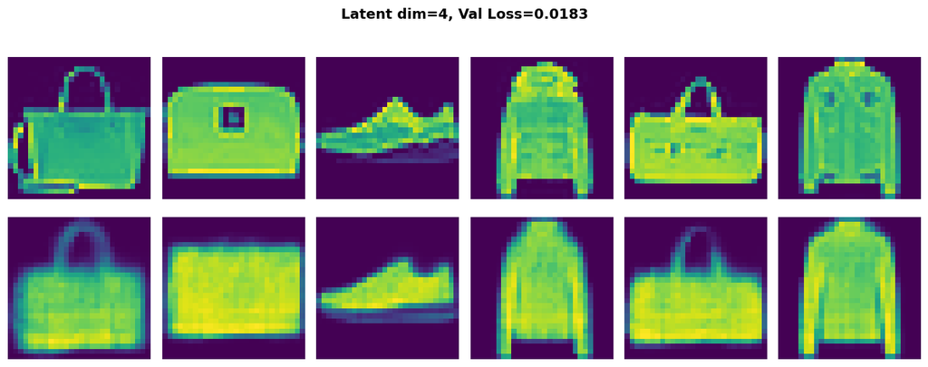

[output not shown]

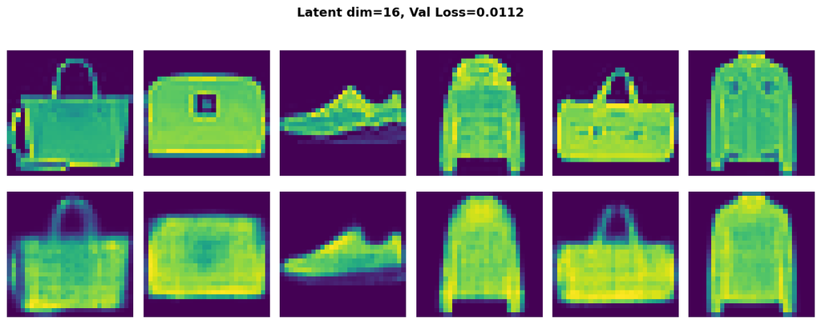

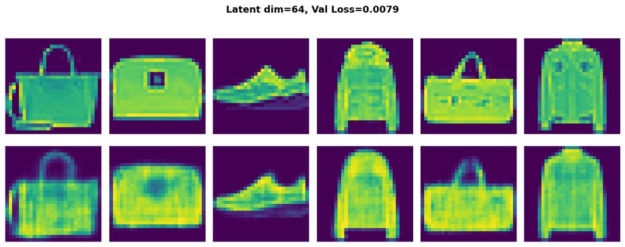

```python
# Порівняльний графік
plt.figure(figsize=(10, 4))
for ld, (m, h, vl) in results_latent.items():
    plt.plot(h.history['val_loss'], label=f'latent={ld} (best={vl:.4f})', linewidth=2)
plt.title('Dense AE: Вплив розміру латентного простору на Val Loss', fontweight='bold')
plt.xlabel('Epoch')
plt.ylabel('MSE Loss')
plt.legend()
plt.grid(True, alpha=0.3)
plt.tight_layout()
plt.show()

# Реконструкції
for ld, (m, h, vl) in results_latent.items():
    show_reconstructions(m, x_val_flat, n=6, title=f'Latent dim={ld}, Val Loss={vl:.4f}')
```

## 4. UseCase 2: Конволюційний Автоенкодер — Очищення від шуму

### 4.1 Підготовка даних (reshape для CNN)

```python
# CNN потребує форму (N, 28, 28, 1)
x_train_cnn = x_train.reshape(-1, 28, 28, 1)
x_val_cnn   = x_val.reshape(-1, 28, 28, 1)
x_test_cnn  = x_test.reshape(-1, 28, 28, 1)

print(f'CNN shape — train: {x_train_cnn.shape}, val: {x_val_cnn.shape}')
```

```
CNN shape — train: (48000, 28, 28, 1), val: (12000, 28, 28, 1)
```

### 4.2 Функції для нанесення різних типів шуму

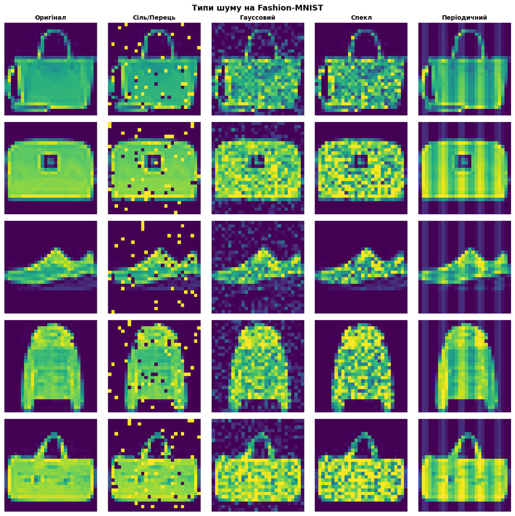

```python
def add_salt_and_pepper_noise(images, prob=0.1):
    """Сіль та перець (імпульсний шум): рандомні білі та чорні пікселі"""
    noisy = images.copy()
    rng = np.random.default_rng(42)
    mask = rng.random(images.shape)
    noisy[mask < prob/2]      = 0.0   # Перець (чорні пікселі)
    noisy[mask > 1 - prob/2]  = 1.0   # Сіль   (білі пікселі)
    return noisy.astype('float32')

def add_gaussian_noise(images, mean=0.0, std=0.15):
    """Гауссовий (нормальний) шум"""
    rng = np.random.default_rng(42)
    noise = rng.normal(mean, std, images.shape).astype('float32')
    return np.clip(images + noise, 0.0, 1.0)

def add_speckle_noise(images, intensity=0.3):
    """Спекл-шум (мультиплікативний)"""
    rng = np.random.default_rng(42)
    noise = rng.normal(0, intensity, images.shape).astype('float32')
    return np.clip(images + images * noise, 0.0, 1.0)

def add_periodic_noise(images, freq=5, amplitude=0.15):
    """Синусоїдальний (періодичний) шум"""
    # Create periodic pattern for a single image
    rows = np.arange(28)
    cols = np.arange(28)
    X, Y = np.meshgrid(cols, rows)
    # Create 2D sinusoidal pattern
    periodic_pattern = amplitude * np.sin(2 * np.pi * freq * X / 28)
    # Add to each image in the batch
    noise = periodic_pattern.reshape(1, 28, 28, 1).astype('float32')
    noisy = images + noise
    return np.clip(noisy, 0.0, 1.0)

# Генерація зашумлених версій
x_train_sp = add_salt_and_pepper_noise(x_train_cnn, prob=0.1)
x_val_sp = add_salt_and_pepper_noise(x_val_cnn, prob=0.1)

x_train_gauss = add_gaussian_noise(x_train_cnn, std=0.15)
x_val_gauss = add_gaussian_noise(x_val_cnn, std=0.15)

x_train_speckle = add_speckle_noise(x_train_cnn, intensity=0.3)
x_val_speckle = add_speckle_noise(x_val_cnn, intensity=0.3)

x_train_periodic = add_periodic_noise(x_train_cnn)
x_val_periodic = add_periodic_noise(x_val_cnn)

# Порівняльна візуалізація типів шуму
noise_variants = {
    'Оригінал':  x_val_cnn,
    'Сіль/Перець': x_val_sp,
    'Гауссовий': x_val_gauss,
    'Спекл':     x_val_speckle,
    'Періодичний': x_val_periodic,
}

fig, axes = plt.subplots(5, 5, figsize=(12, 12))
for col, (name, imgs) in enumerate(noise_variants.items()):
    for row in range(5):
        # Extract image safely
        img = imgs[row]

        # Handle different shapes
        if len(img.shape) == 3:
            if img.shape[-1] == 1:
                img = img[:, :, 0]  # Remove channel dimension

        axes[row, col].imshow(img)
        axes[row, col].axis('off')
        if row == 0:
            axes[row, col].set_title(name, fontsize=10, fontweight='bold')

plt.suptitle('Типи шуму на Fashion-MNIST', fontsize=13, fontweight='bold')
plt.tight_layout()
plt.show()
```

### 4.3 Базовий конволюційний автоенкодер

```python
def build_conv_ae_baseline():

    # input layer
    input_layer = Input(shape=(28, 28, 1))

    # encoding architecture
    encoded_layer1 = Conv2D(64, (3, 3), activation='relu', padding='same')(input_layer)
    encoded_layer1 = MaxPool2D( (2, 2), padding='same')(encoded_layer1)
    encoded_layer2 = Conv2D(32, (3, 3), activation='relu', padding='same')(encoded_layer1)
    encoded_layer2 = MaxPool2D( (2, 2),padding='same')(encoded_layer2)
    encoded_layer3 = Conv2D(16, (3, 3), activation='relu',padding='same')(encoded_layer2)

    latent_view = MaxPool2D( (2, 2), padding='same')(encoded_layer3)

    # decoding architecture
    decoded_layer1 = Conv2D(16, (3, 3), activation='relu', padding='same')(latent_view)
    decoded_layer1 = UpSampling2D((2, 2))(decoded_layer1)
    decoded_layer2 = Conv2D(32, (3, 3), activation='relu', padding='same')(decoded_layer1)
    decoded_layer2 = UpSampling2D((2, 2))(decoded_layer2)
    decoded_layer3 = Conv2D(64, (3, 3), activation='relu')(decoded_layer2)
    decoded_layer3 = UpSampling2D((2, 2))(decoded_layer3)
    output_layer = Conv2D(1, (3, 3), padding='same')(decoded_layer3)

    # compile the model
    model_2 = Model(input_layer, output_layer, name='Conv_AE_Baseline')

    return model_2

conv_ae_base = build_conv_ae_baseline()
conv_ae_base.summary()
```

```
Model: "Conv_AE_Baseline"
```

```
┏━━━━━━━━━━━━━━━━━━━━━━━━━━━━━━━━━┳━━━━━━━━━━━━━━━━━━━━━━━━┳━━━━━━━━━━━━━━━┓
┃ Layer (type)                    ┃ Output Shape           ┃       Param # ┃
┡━━━━━━━━━━━━━━━━━━━━━━━━━━━━━━━━━╇━━━━━━━━━━━━━━━━━━━━━━━━╇━━━━━━━━━━━━━━━┩
│ input_layer_1 (InputLayer)      │ (None, 28, 28, 1)      │             0 │
├─────────────────────────────────┼────────────────────────┼───────────────┤
│ conv2d_7 (Conv2D)               │ (None, 28, 28, 64)     │           640 │
├─────────────────────────────────┼────────────────────────┼───────────────┤
│ max_pooling2d_3 (MaxPooling2D)  │ (None, 14, 14, 64)     │             0 │
├─────────────────────────────────┼────────────────────────┼───────────────┤
│ conv2d_8 (Conv2D)               │ (None, 14, 14, 32)     │        18,464 │
├─────────────────────────────────┼────────────────────────┼───────────────┤
│ max_pooling2d_4 (MaxPooling2D)  │ (None, 7, 7, 32)       │             0 │
├─────────────────────────────────┼────────────────────────┼───────────────┤
│ conv2d_9 (Conv2D)               │ (None, 7, 7, 16)       │         4,624 │
├─────────────────────────────────┼────────────────────────┼───────────────┤
│ max_pooling2d_5 (MaxPooling2D)  │ (None, 4, 4, 16)       │             0 │
├─────────────────────────────────┼────────────────────────┼───────────────┤
│ conv2d_10 (Conv2D)              │ (None, 4, 4, 16)       │         2,320 │
├─────────────────────────────────┼────────────────────────┼───────────────┤
│ up_sampling2d_3 (UpSampling2D)  │ (None, 8, 8, 16)       │             0 │
├─────────────────────────────────┼────────────────────────┼───────────────┤
│ conv2d_11 (Conv2D)              │ (None, 8, 8, 32)       │         4,640 │
├─────────────────────────────────┼────────────────────────┼───────────────┤
│ up_sampling2d_4 (UpSampling2D)  │ (None, 16, 16, 32)     │             0 │
├─────────────────────────────────┼────────────────────────┼───────────────┤
│ conv2d_12 (Conv2D)              │ (None, 14, 14, 64)     │        18,496 │
├─────────────────────────────────┼────────────────────────┼───────────────┤
│ up_sampling2d_5 (UpSampling2D)  │ (None, 28, 28, 64)     │             0 │
├─────────────────────────────────┼────────────────────────┼───────────────┤
│ conv2d_13 (Conv2D)              │ (None, 28, 28, 1)      │           577 │
└─────────────────────────────────┴────────────────────────┴───────────────┘
```

```
 Total params: 49,761 (194.38 KB)
```

```
 Trainable params: 49,761 (194.38 KB)
```

```
 Non-trainable params: 0 (0.00 B)
```

```python
conv_ae_base.compile(optimizer='adam', loss='mse')

es_conv = EarlyStopping(monitor='val_loss', patience=5, restore_best_weights=True, verbose=1)

history_conv_base = conv_ae_base.fit(
    x_train_sp, x_train_cnn,   # Вхід: зашумлений, Вихід: чистий
    epochs=30,
    batch_size=256,
    validation_data=(x_val_sp, x_val_cnn),
    callbacks=[es_conv],
    verbose=1
)
```

```
188/188 ━━━━━━━━━━━━━━━━━━━━ 11s 33ms/step - loss: 0.0374 - val_loss: 0.0216
188/188 ━━━━━━━━━━━━━━━━━━━━ 3s 15ms/step - loss: 0.0194 - val_loss: 0.0179
188/188 ━━━━━━━━━━━━━━━━━━━━ 3s 16ms/step - loss: 0.0172 - val_loss: 0.0165
188/188 ━━━━━━━━━━━━━━━━━━━━ 3s 15ms/step - loss: 0.0159 - val_loss: 0.0154
188/188 ━━━━━━━━━━━━━━━━━━━━ 3s 15ms/step - loss: 0.0151 - val_loss: 0.0148
188/188 ━━━━━━━━━━━━━━━━━━━━ 3s 15ms/step - loss: 0.0144 - val_loss: 0.0143
188/188 ━━━━━━━━━━━━━━━━━━━━ 3s 16ms/step - loss: 0.0139 - val_loss: 0.0137
188/188 ━━━━━━━━━━━━━━━━━━━━ 3s 16ms/step - loss: 0.0134 - val_loss: 0.0135
188/188 ━━━━━━━━━━━━━━━━━━━━ 3s 16ms/step - loss: 0.0131 - val_loss: 0.0130
188/188 ━━━━━━━━━━━━━━━━━━━━ 3s 15ms/step - loss: 0.0128 - val_loss: 0.0127
188/188 ━━━━━━━━━━━━━━━━━━━━ 3s 16ms/step - loss: 0.0125 - val_loss: 0.0125
188/188 ━━━━━━━━━━━━━━━━━━━━ 3s 15ms/step - loss: 0.0123 - val_loss: 0.0132
188/188 ━━━━━━━━━━━━━━━━━━━━ 3s 15ms/step - loss: 0.0121 - val_loss: 0.0120
188/188 ━━━━━━━━━━━━━━━━━━━━ 3s 15ms/step - loss: 0.0119 - val_loss: 0.0118
188/188 ━━━━━━━━━━━━━━━━━━━━ 3s 16ms/step - loss: 0.0117 - val_loss: 0.0116
188/188 ━━━━━━━━━━━━━━━━━━━━ 3s 16ms/step - loss: 0.0115 - val_loss: 0.0115
188/188 ━━━━━━━━━━━━━━━━━━━━ 3s 16ms/step - loss: 0.0114 - val_loss: 0.0122
188/188 ━━━━━━━━━━━━━━━━━━━━ 3s 16ms/step - loss: 0.0113 - val_loss: 0.0111
188/188 ━━━━━━━━━━━━━━━━━━━━ 3s 18ms/step - loss: 0.0111 - val_loss: 0.0111
188/188 ━━━━━━━━━━━━━━━━━━━━ 3s 18ms/step - loss: 0.0110 - val_loss: 0.0114
188/188 ━━━━━━━━━━━━━━━━━━━━ 3s 16ms/step - loss: 0.0109 - val_loss: 0.0108
188/188 ━━━━━━━━━━━━━━━━━━━━ 3s 16ms/step - loss: 0.0107 - val_loss: 0.0108
188/188 ━━━━━━━━━━━━━━━━━━━━ 3s 16ms/step - loss: 0.0107 - val_loss: 0.0107
188/188 ━━━━━━━━━━━━━━━━━━━━ 3s 16ms/step - loss: 0.0105 - val_loss: 0.0105
188/188 ━━━━━━━━━━━━━━━━━━━━ 3s 16ms/step - loss: 0.0104 - val_loss: 0.0109
188/188 ━━━━━━━━━━━━━━━━━━━━ 3s 16ms/step - loss: 0.0105 - val_loss: 0.0105
188/188 ━━━━━━━━━━━━━━━━━━━━ 3s 16ms/step - loss: 0.0102 - val_loss: 0.0103
188/188 ━━━━━━━━━━━━━━━━━━━━ 3s 16ms/step - loss: 0.0103 - val_loss: 0.0102
188/188 ━━━━━━━━━━━━━━━━━━━━ 3s 16ms/step - loss: 0.0101 - val_loss: 0.0101
188/188 ━━━━━━━━━━━━━━━━━━━━ 3s 16ms/step - loss: 0.0101 - val_loss: 0.0101
Restoring model weights from the end of the best epoch: 30.
```

```python
def plot_loss(history, title='Loss'):
    plt.figure(figsize=(8, 4))
    plt.plot(history.history['loss'],     label='Train Loss', linewidth=2)
    plt.plot(history.history['val_loss'], label='Val Loss',   linewidth=2)
    plt.title(title, fontsize=13, fontweight='bold')
    plt.xlabel('Epoch')
    plt.ylabel('MSE Loss')
    plt.legend()
    plt.grid(True, alpha=0.3)
    plt.tight_layout()
    plt.show()
```

```python
def show_reconstructions(model, x_flat, n=8, title='Реконструкція'):
    preds = model.predict(x_flat[:n], verbose=0)
    fig, axes = plt.subplots(2, n, figsize=(2*n, 5))
    for i in range(n):
        axes[0, i].imshow(x_flat[i].reshape(28, 28))
        axes[0, i].axis('off')
        axes[1, i].imshow(preds[i].reshape(28, 28))
        axes[1, i].axis('off')
    axes[0, 0].set_ylabel('Оригінал', fontsize=11)
    axes[1, 0].set_ylabel('Відновлено', fontsize=11)
    plt.suptitle(title, fontsize=13, fontweight='bold')
    plt.tight_layout()
    plt.show()
```

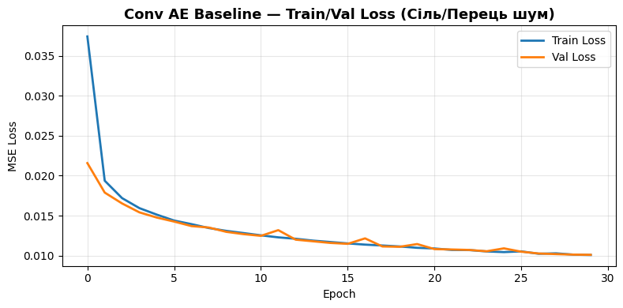

```python
plot_loss(history_conv_base, 'Conv AE Baseline — Train/Val Loss (Сіль/Перець шум)')
```

```python
def show_denoising(model, x_noisy, x_clean, n=8, title='Деноізинг'):
    preds = model.predict(x_noisy[:n], verbose=0)
    fig, axes = plt.subplots(3, n, figsize=(2*n, 7))
    for i in range(n):
        axes[0, i].imshow(x_clean[i].reshape(28,28))
        axes[0, i].axis('off')
        axes[1, i].imshow(x_noisy[i].reshape(28,28))
        axes[1, i].axis('off')
        axes[2, i].imshow(preds[i].reshape(28,28))
        axes[2, i].axis('off')
    axes[0, 0].set_ylabel('Оригінал', fontsize=10)
    axes[1, 0].set_ylabel('Зашумлено', fontsize=10)
    axes[2, 0].set_ylabel('Відновлено', fontsize=10)
    plt.suptitle(title, fontsize=13, fontweight='bold')
    plt.tight_layout()
    plt.show()
```

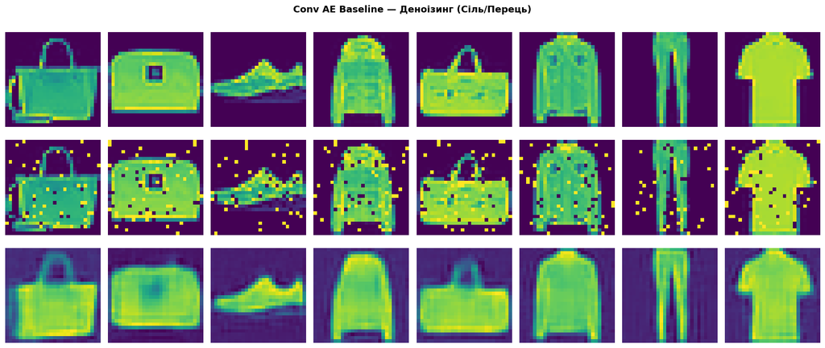

```python
show_denoising(conv_ae_base, x_val_sp, x_val_cnn, title='Conv AE Baseline — Деноізинг (Сіль/Перець)')
```

### 4.4 Покращений конволюційний автоенкодер (більше шарів + BatchNorm)

```python
def build_conv_ae_improved():
    input_layer = Input(shape=(28, 28, 1), name='input')

    # Encoder (більше фільтрів + BatchNorm)
    x = Conv2D(128, (3,3), activation='relu', padding='same')(input_layer)
    x = BatchNormalization()(x)
    x = Conv2D(128, (3,3), activation='relu', padding='same')(x)
    x = MaxPool2D((2,2), padding='same')(x)          # 14x14

    x = Conv2D(64, (3,3), activation='relu', padding='same')(x)
    x = BatchNormalization()(x)
    x = Conv2D(64, (3,3), activation='relu', padding='same')(x)
    x = MaxPool2D((2,2), padding='same')(x)           # 7x7

    x = Conv2D(32, (3,3), activation='relu', padding='same')(x)
    x = BatchNormalization()(x)
    latent = MaxPool2D((2,2), padding='same', name='latent')(x)  # 4x4

    # Decoder
    x = Conv2D(32, (3,3), activation='relu', padding='same')(latent)
    x = BatchNormalization()(x)
    x = UpSampling2D((2,2))(x)                        # 8x8

    x = Conv2D(64, (3,3), activation='relu', padding='same')(x)
    x = BatchNormalization()(x)
    x = Conv2D(64, (3,3), activation='relu', padding='same')(x)
    x = UpSampling2D((2,2))(x)                        # 16x16

    x = Conv2D(128, (3,3), activation='relu')(x)      # 14x14
    x = BatchNormalization()(x)
    x = Conv2D(128, (3,3), activation='relu', padding='same')(x)
    x = UpSampling2D((2,2))(x)                        # 28x28

    output_layer = Conv2D(1, (3,3), padding='same', activation='sigmoid', name='output')(x)

    model = Model(input_layer, output_layer, name='Conv_AE_Improved')
    return model

conv_ae_imp = build_conv_ae_improved()
conv_ae_imp.summary()
```

```
Model: "Conv_AE_Improved"
```

```
┏━━━━━━━━━━━━━━━━━━━━━━━━━━━━━━━━━┳━━━━━━━━━━━━━━━━━━━━━━━━┳━━━━━━━━━━━━━━━┓
┃ Layer (type)                    ┃ Output Shape           ┃       Param # ┃
┡━━━━━━━━━━━━━━━━━━━━━━━━━━━━━━━━━╇━━━━━━━━━━━━━━━━━━━━━━━━╇━━━━━━━━━━━━━━━┩
│ input (InputLayer)              │ (None, 28, 28, 1)      │             0 │
├─────────────────────────────────┼────────────────────────┼───────────────┤
│ conv2d_14 (Conv2D)              │ (None, 28, 28, 128)    │         1,280 │
├─────────────────────────────────┼────────────────────────┼───────────────┤
│ batch_normalization             │ (None, 28, 28, 128)    │           512 │
│ (BatchNormalization)            │                        │               │
├─────────────────────────────────┼────────────────────────┼───────────────┤
│ conv2d_15 (Conv2D)              │ (None, 28, 28, 128)    │       147,584 │
├─────────────────────────────────┼────────────────────────┼───────────────┤
│ max_pooling2d_6 (MaxPooling2D)  │ (None, 14, 14, 128)    │             0 │
├─────────────────────────────────┼────────────────────────┼───────────────┤
│ conv2d_16 (Conv2D)              │ (None, 14, 14, 64)     │        73,792 │
├─────────────────────────────────┼────────────────────────┼───────────────┤
│ batch_normalization_1           │ (None, 14, 14, 64)     │           256 │
│ (BatchNormalization)            │                        │               │
├─────────────────────────────────┼────────────────────────┼───────────────┤
│ conv2d_17 (Conv2D)              │ (None, 14, 14, 64)     │        36,928 │
├─────────────────────────────────┼────────────────────────┼───────────────┤
│ max_pooling2d_7 (MaxPooling2D)  │ (None, 7, 7, 64)       │             0 │
├─────────────────────────────────┼────────────────────────┼───────────────┤
│ conv2d_18 (Conv2D)              │ (None, 7, 7, 32)       │        18,464 │
├─────────────────────────────────┼────────────────────────┼───────────────┤
│ batch_normalization_2           │ (None, 7, 7, 32)       │           128 │
│ (BatchNormalization)            │                        │               │
├─────────────────────────────────┼────────────────────────┼───────────────┤
│ latent (MaxPooling2D)           │ (None, 4, 4, 32)       │             0 │
├─────────────────────────────────┼────────────────────────┼───────────────┤
│ conv2d_19 (Conv2D)              │ (None, 4, 4, 32)       │         9,248 │
├─────────────────────────────────┼────────────────────────┼───────────────┤
│ batch_normalization_3           │ (None, 4, 4, 32)       │           128 │
│ (BatchNormalization)            │                        │               │
├─────────────────────────────────┼────────────────────────┼───────────────┤
│ up_sampling2d_6 (UpSampling2D)  │ (None, 8, 8, 32)       │             0 │
├─────────────────────────────────┼────────────────────────┼───────────────┤
│ conv2d_20 (Conv2D)              │ (None, 8, 8, 64)       │        18,496 │
├─────────────────────────────────┼────────────────────────┼───────────────┤
│ batch_normalization_4           │ (None, 8, 8, 64)       │           256 │
│ (BatchNormalization)            │                        │               │
├─────────────────────────────────┼────────────────────────┼───────────────┤
│ conv2d_21 (Conv2D)              │ (None, 8, 8, 64)       │        36,928 │
├─────────────────────────────────┼────────────────────────┼───────────────┤
│ up_sampling2d_7 (UpSampling2D)  │ (None, 16, 16, 64)     │             0 │
├─────────────────────────────────┼────────────────────────┼───────────────┤
│ conv2d_22 (Conv2D)              │ (None, 14, 14, 128)    │        73,856 │
├─────────────────────────────────┼────────────────────────┼───────────────┤
│ batch_normalization_5           │ (None, 14, 14, 128)    │           512 │
│ (BatchNormalization)            │                        │               │
├─────────────────────────────────┼────────────────────────┼───────────────┤
│ conv2d_23 (Conv2D)              │ (None, 14, 14, 128)    │       147,584 │
├─────────────────────────────────┼────────────────────────┼───────────────┤
│ up_sampling2d_8 (UpSampling2D)  │ (None, 28, 28, 128)    │             0 │
├─────────────────────────────────┼────────────────────────┼───────────────┤
│ output (Conv2D)                 │ (None, 28, 28, 1)      │         1,153 │
└─────────────────────────────────┴────────────────────────┴───────────────┘
```

```
 Total params: 567,105 (2.16 MB)
```

```
 Trainable params: 566,209 (2.16 MB)
```

```
 Non-trainable params: 896 (3.50 KB)
```

```python
conv_ae_imp.compile(optimizer=keras.optimizers.Adam(learning_rate=1e-3), loss='mse')

es_conv2 = EarlyStopping(monitor='val_loss', patience=5, restore_best_weights=True, verbose=1)

history_conv_imp = conv_ae_imp.fit(
    x_train_sp, x_train_cnn,
    epochs=30,
    batch_size=256,
    validation_data=(x_val_sp, x_val_cnn),
    callbacks=[es_conv2],
    verbose=1
)
```

```
188/188 ━━━━━━━━━━━━━━━━━━━━ 48s 167ms/step - loss: 0.0209 - val_loss: 0.0979
188/188 ━━━━━━━━━━━━━━━━━━━━ 14s 73ms/step - loss: 0.0125 - val_loss: 0.0725
188/188 ━━━━━━━━━━━━━━━━━━━━ 14s 74ms/step - loss: 0.0106 - val_loss: 0.0289
188/188 ━━━━━━━━━━━━━━━━━━━━ 14s 75ms/step - loss: 0.0096 - val_loss: 0.0099
188/188 ━━━━━━━━━━━━━━━━━━━━ 14s 76ms/step - loss: 0.0088 - val_loss: 0.0086
188/188 ━━━━━━━━━━━━━━━━━━━━ 14s 77ms/step - loss: 0.0084 - val_loss: 0.0093
188/188 ━━━━━━━━━━━━━━━━━━━━ 14s 77ms/step - loss: 0.0079 - val_loss: 0.0086
188/188 ━━━━━━━━━━━━━━━━━━━━ 15s 78ms/step - loss: 0.0077 - val_loss: 0.0075
188/188 ━━━━━━━━━━━━━━━━━━━━ 15s 80ms/step - loss: 0.0073 - val_loss: 0.0072
188/188 ━━━━━━━━━━━━━━━━━━━━ 15s 81ms/step - loss: 0.0070 - val_loss: 0.0071
188/188 ━━━━━━━━━━━━━━━━━━━━ 15s 82ms/step - loss: 0.0069 - val_loss: 0.0068
188/188 ━━━━━━━━━━━━━━━━━━━━ 16s 82ms/step - loss: 0.0067 - val_loss: 0.0067
188/188 ━━━━━━━━━━━━━━━━━━━━ 16s 83ms/step - loss: 0.0066 - val_loss: 0.0094
188/188 ━━━━━━━━━━━━━━━━━━━━ 16s 84ms/step - loss: 0.0063 - val_loss: 0.0068
188/188 ━━━━━━━━━━━━━━━━━━━━ 16s 84ms/step - loss: 0.0062 - val_loss: 0.0069
188/188 ━━━━━━━━━━━━━━━━━━━━ 16s 85ms/step - loss: 0.0060 - val_loss: 0.0068
188/188 ━━━━━━━━━━━━━━━━━━━━ 16s 86ms/step - loss: 0.0060 - val_loss: 0.0062
188/188 ━━━━━━━━━━━━━━━━━━━━ 16s 87ms/step - loss: 0.0057 - val_loss: 0.0059
188/188 ━━━━━━━━━━━━━━━━━━━━ 16s 85ms/step - loss: 0.0057 - val_loss: 0.0063
188/188 ━━━━━━━━━━━━━━━━━━━━ 16s 83ms/step - loss: 0.0056 - val_loss: 0.0065
188/188 ━━━━━━━━━━━━━━━━━━━━ 16s 84ms/step - loss: 0.0055 - val_loss: 0.0058
188/188 ━━━━━━━━━━━━━━━━━━━━ 16s 84ms/step - loss: 0.0054 - val_loss: 0.0055
188/188 ━━━━━━━━━━━━━━━━━━━━ 16s 85ms/step - loss: 0.0053 - val_loss: 0.0054
188/188 ━━━━━━━━━━━━━━━━━━━━ 20s 83ms/step - loss: 0.0052 - val_loss: 0.0053
188/188 ━━━━━━━━━━━━━━━━━━━━ 16s 83ms/step - loss: 0.0052 - val_loss: 0.0054
188/188 ━━━━━━━━━━━━━━━━━━━━ 16s 84ms/step - loss: 0.0051 - val_loss: 0.0057
188/188 ━━━━━━━━━━━━━━━━━━━━ 16s 84ms/step - loss: 0.0051 - val_loss: 0.0063
188/188 ━━━━━━━━━━━━━━━━━━━━ 16s 85ms/step - loss: 0.0049 - val_loss: 0.0053
188/188 ━━━━━━━━━━━━━━━━━━━━ 16s 85ms/step - loss: 0.0049 - val_loss: 0.0052
188/188 ━━━━━━━━━━━━━━━━━━━━ 16s 85ms/step - loss: 0.0048 - val_loss: 0.0051
Restoring model weights from the end of the best epoch: 30.
```

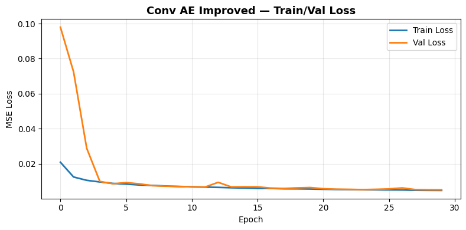

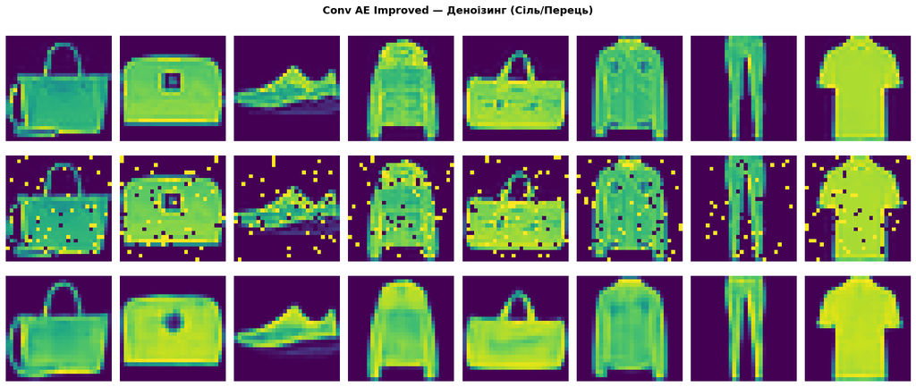

```python
plot_loss(history_conv_imp, 'Conv AE Improved — Train/Val Loss')
show_denoising(conv_ae_imp, x_val_sp, x_val_cnn, title='Conv AE Improved — Деноізинг (Сіль/Перець)')
```

## 5. Порівняння: Dense vs Конволюційний автоенкодер

### 5.1 Кількісне порівняння

```python
def mse_score(model, x_input, x_target):
    preds = model.predict(x_input, verbose=0)
    return np.mean((preds - x_target.reshape(preds.shape))**2)

# Dense (реконструкція без шуму)
mse_dense_base = mse_score(dense_ae_base, x_val_flat, x_val_flat)
mse_dense_imp  = mse_score(dense_ae_imp,  x_val_flat, x_val_flat)

# CNN (деноізинг: вхід зашумлений, ціль — чистий)
mse_conv_base  = mse_score(conv_ae_base, x_val_sp, x_val_cnn)
mse_conv_imp   = mse_score(conv_ae_imp,  x_val_sp, x_val_cnn)

print('=' * 55)
print(f'{"Модель":<35} {"Val MSE":>10}')
print('=' * 55)
print(f'{"Dense AE Baseline (latent=10)":<35} {mse_dense_base:>10.6f}')
print(f'{"Dense AE Improved (BN+Drop, latent=32)":<35} {mse_dense_imp:>10.6f}')
print(f'{"Conv AE Baseline (деноізинг)":<35} {mse_conv_base:>10.6f}')
print(f'{"Conv AE Improved (BN+more layers)":<35} {mse_conv_imp:>10.6f}')
print('=' * 55)
```

```
=======================================================
Модель                                 Val MSE
=======================================================
Dense AE Baseline (latent=10)         0.012105
Dense AE Improved (BN+Drop, latent=32)   0.012379
Conv AE Baseline (деноізинг)          0.010096
Conv AE Improved (BN+more layers)     0.005147
=======================================================
```

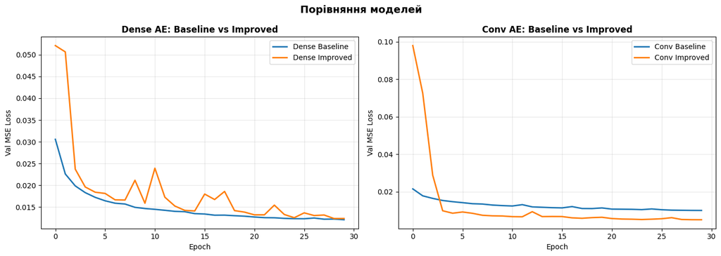

```python
# Порівняння графіків втрат
fig, (ax1, ax2) = plt.subplots(1, 2, figsize=(14, 5))

ax1.plot(history_base.history['val_loss'], label='Dense Baseline', linewidth=2)
ax1.plot(history_imp.history['val_loss'],  label='Dense Improved', linewidth=2)
ax1.set_title('Dense AE: Baseline vs Improved', fontweight='bold')
ax1.set_xlabel('Epoch'); ax1.set_ylabel('Val MSE Loss')
ax1.legend(); ax1.grid(True, alpha=0.3)

ax2.plot(history_conv_base.history['val_loss'], label='Conv Baseline', linewidth=2)
ax2.plot(history_conv_imp.history['val_loss'],  label='Conv Improved', linewidth=2)
ax2.set_title('Conv AE: Baseline vs Improved', fontweight='bold')
ax2.set_xlabel('Epoch'); ax2.set_ylabel('Val MSE Loss')
ax2.legend(); ax2.grid(True, alpha=0.3)

plt.suptitle('Порівняння моделей', fontsize=14, fontweight='bold')
plt.tight_layout()
plt.show()
```

### 5.2 Дослідження локальних особливостей (Dense vs CNN)

Dense-автоенкодер опрацьовує всі пікселі зображення як один вектор — він **не враховує просторові зв'язки** між пікселями. CNN завдяки локальним фільтрам здатний **виявляти локальні патерни** (краї, текстури, форми), тому краще зберігає структуру деталей.

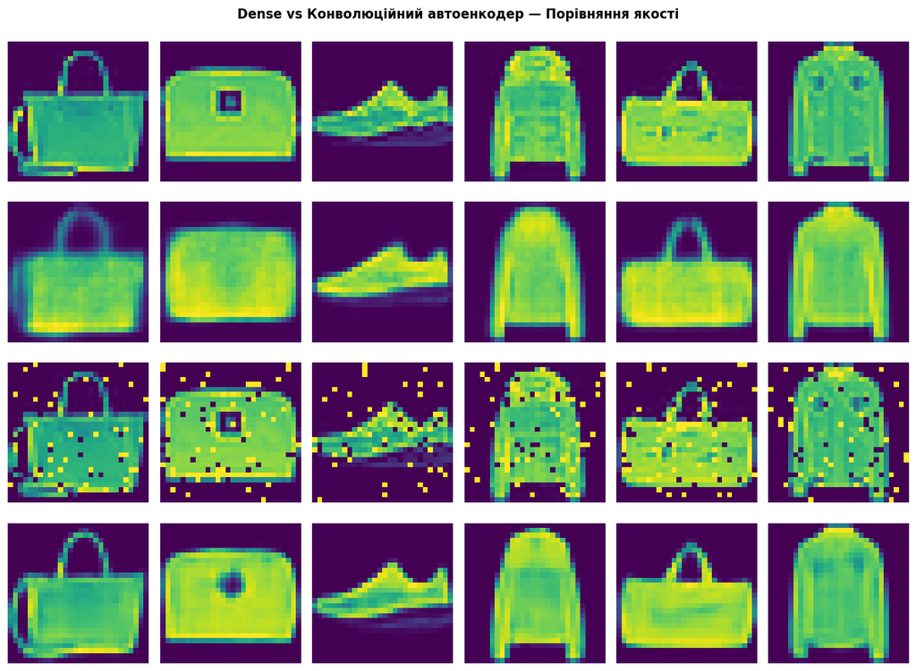

```python
# Порівняння Dense vs CNN: реконструкція одних і тих самих зображень
n = 6
idx = np.arange(n)

preds_dense = dense_ae_imp.predict(x_val_flat[idx], verbose=0)
preds_conv  = conv_ae_imp.predict(x_val_sp[idx], verbose=0)

fig, axes = plt.subplots(4, n, figsize=(2*n, 9))
row_labels = ['Оригінал', 'Dense AE', 'Зашумлений', 'Conv AE (деноізинг)']

for i in range(n):
    axes[0, i].imshow(x_val_flat[i].reshape(28,28))
    axes[1, i].imshow(preds_dense[i].reshape(28,28))
    axes[2, i].imshow(x_val_sp[i].reshape(28,28))
    axes[3, i].imshow(preds_conv[i].reshape(28,28))
    for r in range(4):
        axes[r, i].axis('off')

for r, label in enumerate(row_labels):
    axes[r, 0].set_ylabel(label, fontsize=9, fontweight='bold')

plt.suptitle('Dense vs Конволюційний автоенкодер — Порівняння якості', fontsize=12, fontweight='bold')
plt.tight_layout()
plt.show()
```

## 6. Різні типи шуму — Порівняльне дослідження з Conv AE

Навчаємо базовий конволюційний автоенкодер для кожного типу шуму та порівнюємо результати.

```python
noise_datasets = {
    'Сіль/Перець':  (x_train_sp,       x_val_sp),
    'Гауссовий':    (x_train_gauss,    x_val_gauss),
    'Спекл':        (x_train_speckle,  x_val_speckle),
    'Періодичний':  (x_train_periodic, x_val_periodic),
}
```

```python
denoiser_models   = {}
denoiser_histories = {}

for noise_name, (trn, vld) in noise_datasets.items():
    print(f'\n=== Навчання для шуму: {noise_name} ===')
    m = build_conv_ae_baseline()
    m.compile(optimizer='adam', loss='mse')
    es = EarlyStopping(monitor='val_loss', patience=5, restore_best_weights=True, verbose=0)
    h = m.fit(trn, x_train_cnn,
              epochs=30, batch_size=256,
              validation_data=(vld, x_val_cnn),
              callbacks=[es], verbose=0)
    best_vl = min(h.history['val_loss'])
    print(f'  Best val_loss: {best_vl:.6f}, epochs: {len(h.history["loss"])}')
    denoiser_models[noise_name]    = m
    denoiser_histories[noise_name] = h
```

```
=== Навчання для шуму: Сіль/Перець ===
  Best val_loss: 0.010029, epochs: 30

=== Навчання для шуму: Гауссовий ===
  Best val_loss: 0.010155, epochs: 30

=== Навчання для шуму: Спекл ===
  Best val_loss: 0.010166, epochs: 30

=== Навчання для шуму: Періодичний ===
  Best val_loss: 0.009000, epochs: 30
```

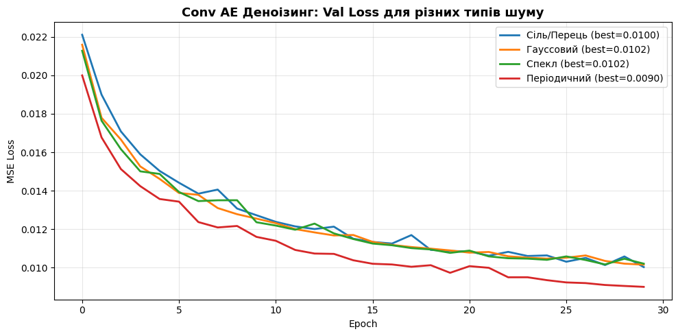

```python
# Порівняльний графік loss для різних типів шуму
plt.figure(figsize=(10, 5))
for noise_name, h in denoiser_histories.items():
    best = min(h.history['val_loss'])
    plt.plot(h.history['val_loss'], label=f'{noise_name} (best={best:.4f})', linewidth=2)
plt.title('Conv AE Деноізинг: Val Loss для різних типів шуму', fontsize=13, fontweight='bold')
plt.xlabel('Epoch')
plt.ylabel('MSE Loss')
plt.legend()
plt.grid(True, alpha=0.3)
plt.tight_layout()
plt.show()
```

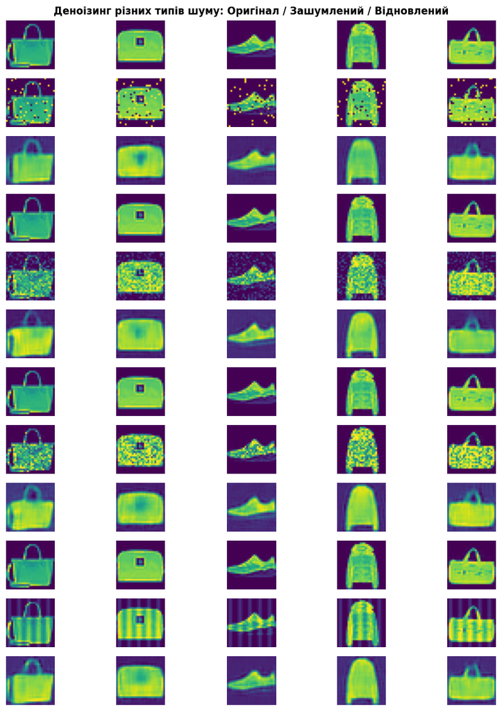

```python
# Візуалізація результатів деноізингу для кожного типу шуму
n_samples = 5

fig, axes = plt.subplots(len(noise_datasets)*3, n_samples, figsize=(2*n_samples, 3*len(noise_datasets)))

for row_group, (noise_name, (trn, vld)) in enumerate(noise_datasets.items()):
    model = denoiser_models[noise_name]
    preds = model.predict(vld[:n_samples], verbose=0)

    r0 = row_group * 3
    for i in range(n_samples):
        axes[r0,   i].imshow(x_val_cnn[i].reshape(28,28))
        axes[r0+1, i].imshow(vld[i].reshape(28,28))
        axes[r0+2, i].imshow(preds[i].reshape(28,28))
        for r in range(3):
            axes[r0+r, i].axis('off')

    axes[r0,   0].set_ylabel(f'{noise_name}\nОригінал',   fontsize=8)
    axes[r0+1, 0].set_ylabel(f'{noise_name}\nЗашумлений', fontsize=8)
    axes[r0+2, 0].set_ylabel(f'{noise_name}\nВідновлено', fontsize=8)

plt.suptitle('Деноізинг різних типів шуму: Оригінал / Зашумлений / Відновлений',
             fontsize=12, fontweight='bold')
plt.tight_layout()
plt.show()
```

## 7. Зведені висновки

```python
print('=' * 65)
print('ПОРІВНЯННЯ ВСІХ МОДЕЛЕЙ — ФІНАЛЬНА ТАБЛИЦЯ')
print('=' * 65)
print(f'{"Модель":<42} {"Val MSE":>10} {"Параметри":>12}')
print('-' * 65)

models_info = [
    ('Dense AE Baseline (latent=10)',    dense_ae_base, x_val_flat, x_val_flat),
    ('Dense AE Improved (BN+latent=32)', dense_ae_imp,  x_val_flat, x_val_flat),
    ('Conv AE Baseline (S&P noise)',      conv_ae_base,  x_val_sp,   x_val_cnn),
    ('Conv AE Improved (BN+more layers)',conv_ae_imp,   x_val_sp,   x_val_cnn),
]

for name, model, x_in, x_target in models_info:
    mse = mse_score(model, x_in, x_target)
    params = model.count_params()
    print(f'{name:<42} {mse:>10.6f} {params:>12,}')

print('=' * 65)

print()
print('ДЕНОІЗИНГ ЗА ТИПАМИ ШУМУ (Conv AE):')
print('-' * 45)
for noise_name, (trn, vld) in noise_datasets.items():
    m = denoiser_models[noise_name]
    mse = mse_score(m, vld, x_val_cnn)
    best = min(denoiser_histories[noise_name].history['val_loss'])
    print(f'{noise_name:<20} val_loss = {best:.6f}')
print('=' * 45)
```

```
=================================================================
ПОРІВНЯННЯ ВСІХ МОДЕЛЕЙ — ФІНАЛЬНА ТАБЛИЦЯ
=================================================================
Модель                                        Val MSE    Параметри
-----------------------------------------------------------------
Dense AE Baseline (latent=10)                0.012105    6,368,794
Dense AE Improved (BN+latent=32)             0.012379    2,951,472
Conv AE Baseline (S&P noise)                 0.010096       49,761
Conv AE Improved (BN+more layers)            0.005147      567,105
=================================================================

ДЕНОІЗИНГ ЗА ТИПАМИ ШУМУ (Conv AE):
---------------------------------------------
Сіль/Перець          val_loss = 0.010029
Гауссовий            val_loss = 0.010155
Спекл                val_loss = 0.010166
Періодичний          val_loss = 0.009000
=============================================
```

## Висновки

Під час виконання лабораторної роботи було реалізовано та досліджено різні архітектури автоенкодерів за допомогою фреймворку Keras. За результатами експериментів та аналізу отриманих метрик можна зробити наступні висновки:

**1. Дослідження глибокого та конволюційного автоенкодерів**

- **Глибокий автоенкодер** використовує повнозв'язні шари. Для роботи з ним зображення попередньо "витягується" в одновимірний вектор, що призводить до повної втрати інформації про просторову структуру пікселів. Незважаючи на величезну кількість параметрів, він видає більш розмиті результати реконструкції.
- **Конволюційний автоенкодер** працює безпосередньо з 2D-зображеннями, використовуючи згортки. Він виявився ефективнішим: має значно меншу кількість параметрів для тренування, але при цьому забезпечує кращу якість відновлення і швидше сходиться під час навчання.

**2. Зміна параметрів глибокого автоенкодера**

- Додавання глибших шарів згортки та пулінгу у кодері дозволяє виділяти складніші ознаки.
- Дзеркальне використання upsampling у декодері симетрично повертає розмірність. Перебудова моделі зі збільшенням кількості фільтрів на ранніх шарах та їх зменшенням у латентному поданні дала змогу отримати більш деталізовані границі та текстури на відновлених зображеннях.

**4. Дослідження виділення локальних особливостей**

- Конволюційний автоенкодер значно краще виділяє локальні особливості. Завдяки природі операції згортки, фільтри проходять по всьому зображенню і вивчають просторові ієрархії, деталі та текстури зберігаються більше.
- Dense-автоенкодер намагається знайти глобальні залежності між всіма пікселями одночасно, тому локальні особливості губляться або сильно розмиваються.

**5. Нанесення шумів та відновлення зображень**

- Під час навчання на вхід подавалися зображення з навмисно доданим шумом, а цільовим виходом були чисті оригінальні зображення.
- Модель навчилася відновлювати первісну структуру об'єктів, ігноруючи випадкові шумові пікселі.